# Supervised learning with tidymodels

Jose M Sallan

10/04/2021

# Supervised learning

# Supervised learning

**Supervised learning** consists of applying to unseen data a function obtained (learned, trained) from a **training set** of labelled data to make a prediction.

Two supervised learning tasks:

- **Classification:** to identify the class to which an observation belongs. The outcome is the prediction of the level of a **categorical variable**, or the probability to having each of the levels.
- **Regression** (numerical prediction): to predict the value of a numerical value for each observation. The outcome is a **numerical variable**.

# Spam detection

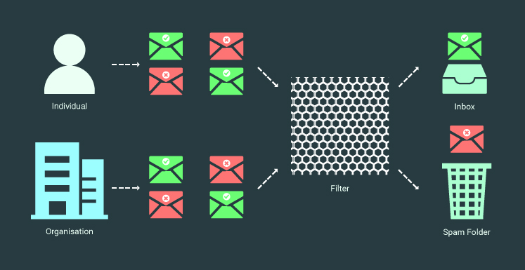

A **classification** problem:

- **Outcome variable:** is the mail ham or spam?
- **Traning set:** a set of emails, with a label indicating if it is ham or spam.

# Housing prices

[figure not shown]

A **regression** problem:

- **Outcome variable:** what is the price of a house?
- **Training set:** a list of houses from which we know the price.

# How to train a model?

Our input is a data set with **features** (variables) for each observation and the value of the outcome variable.

Examples of features:

- Spam detection: email metadata, email content.
- Housing prices: location, area, number of rooms, apartment / house…
- Image recognition: RGB pixels of image.

# How to train a model?

We don’t have unseen data, so we need to split data into two sets:

- **Train set:** observations to define (learn, train) the model.
- **Test set:** observations to examine model performance (replaces unseen data).

The test set must **never be used to build the model**, only for evaluation of performance of the final model.

# The bias-variance tradeoff

When defining a supervised learning model we want to minimize bias and variance:

- **Bias error** comes from wrong assumptions in the learning algorithm: an algorithm with high bias is **underfitting** the data.
- **Variance error** comes from high sensitivity of the model to the values of the training set: an algorithm with high variance is **overfitting** the data.

# The bias-variance tradeoff

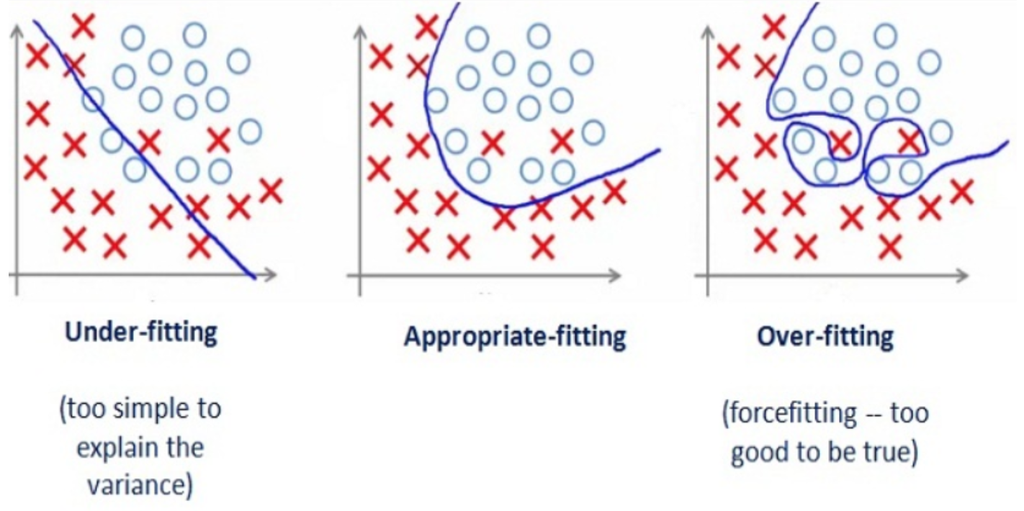

Source: http://bit.ly/3rdcULH

- **High bias:** equally bad values of performance in training and test sets.
- **High variance:** very good performance on train test, worse performance on test set.

We can’t examine variance bias until we have chosen a model, so we better do not look for a too high performance in the trained model.

# Steps to build a supervised learning model

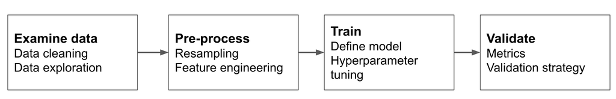

# Implementing supervised learning

[figure not shown]

# Implementing supervised learning

[figure not shown]

See vignette at:

https://rviews.rstudio.com/2019/06/19/a-gentle-intro-to-tidymodels/

# Classification with tidymodels

# A minimal classification workflow

Let’s see a minimal `tidymodels` workflow for a classification problem:

```r
library(tidymodels)
```

Let’s consider the `iris` dataset:

```r
iris %>% glimpse()
```

```
## Rows: 150
## Columns: 5
## $ Sepal.Length <dbl> 5.1, 4.9, 4.7, 4.6, 5.0, 5.4, 4.6, 5.0, 4.4, 4.9, 5.4, 4.…
## $ Sepal.Width  <dbl> 3.5, 3.0, 3.2, 3.1, 3.6, 3.9, 3.4, 3.4, 2.9, 3.1, 3.7, 3.…
## $ Petal.Length <dbl> 1.4, 1.4, 1.3, 1.5, 1.4, 1.7, 1.4, 1.5, 1.4, 1.5, 1.5, 1.…
## $ Petal.Width  <dbl> 0.2, 0.2, 0.2, 0.2, 0.2, 0.4, 0.3, 0.2, 0.2, 0.1, 0.2, 0.…
## $ Species      <fct> setosa, setosa, setosa, setosa, setosa, setosa, setosa, s…
```

# Split into train and test sets

We use the `initial_split` function of `rsample` to define train and test sets:

```r
set.seed(1212)
iris_split <- initial_split(iris, prop = 0.6)
```

```r
training(iris_split) %>% glimpse() #train set
```

```
## Rows: 90
## Columns: 5
## $ Sepal.Length <dbl> 6.3, 7.3, 7.2, 6.1, 5.0, 6.5, 5.4, 7.4, 5.9, 4.4, 4.6, 5.…
## $ Sepal.Width  <dbl> 3.4, 2.9, 3.2, 2.9, 3.5, 2.8, 3.9, 2.8, 3.0, 3.0, 3.1, 2.…
## $ Petal.Length <dbl> 5.6, 6.3, 6.0, 4.7, 1.6, 4.6, 1.7, 6.1, 5.1, 1.3, 1.5, 4.…
## $ Petal.Width  <dbl> 2.4, 1.8, 1.8, 1.4, 0.6, 1.5, 0.4, 1.9, 1.8, 0.2, 0.2, 1.…
## $ Species      <fct> virginica, virginica, virginica, versicolor, setosa, vers…
```

```r
testing(iris_split) %>% glimpse() # test set
```

```
## Rows: 60
## Columns: 5
## $ Sepal.Length <dbl> 4.9, 5.0, 4.4, 4.9, 5.4, 4.8, 4.8, 5.8, 5.4, 5.1, 5.7, 5.…
## $ Sepal.Width  <dbl> 3.0, 3.6, 2.9, 3.1, 3.7, 3.4, 3.0, 4.0, 3.9, 3.5, 3.8, 3.…
## $ Petal.Length <dbl> 1.4, 1.4, 1.4, 1.5, 1.5, 1.6, 1.4, 1.2, 1.3, 1.4, 1.7, 1.…
## $ Petal.Width  <dbl> 0.2, 0.2, 0.2, 0.1, 0.2, 0.2, 0.1, 0.2, 0.4, 0.3, 0.3, 0.…
## $ Species      <fct> setosa, setosa, setosa, setosa, setosa, setosa, setosa, s…
```

# Pre-processing with a recipe

We use the `recipes` package for data pre-processing:

```r
iris_recipe <- training(iris_split) %>%
  recipe(Species ~.) %>%
  step_corr(all_predictors()) %>%
  step_center(all_predictors(), -all_outcomes()) %>%
  step_scale(all_predictors(), -all_outcomes()) %>%
  prep()
```

- `step_corr` removes highly correlated variables,
- `step_center` substracts the mean (obtained from the train set),
- `step_scale` divides by standard deviation (obtained from the train set).

# Pre-processing with a recipe

```r
iris_recipe
```

```
## Recipe
##
## Inputs:
##
##       role #variables
##    outcome          1
##  predictor          4
##
## Training data contained 90 data points and no missing data.
##
## Operations:
##
## Correlation filter on Petal.Length [trained]
## Centering for Sepal.Length, Sepal.Width, Petal.Width [trained]
## Scaling for Sepal.Length, Sepal.Width, Petal.Width [trained]
```

The recipe has removed the `Petal.Length` variable.

# Building a model

The `parnsip` package provides algorithms for classification and regression from several sources (`engines` in parsnip parlance). Here we train a random forest model using the `ranger` package.

```r
iris_ranger <- rand_forest(trees = 100, mode = "classification") %>%
  set_engine("ranger")
```

# Fitting the model

We use the `workflow` package to integrate the recipe and the model in a workflow, and we fit the model using the train set:

```r
iris_ranger_wf <- workflow() %>%
  add_recipe(iris_recipe) %>%
  add_model(iris_ranger) %>%
  fit(training(iris_split))
```

# Fitting the model

```r
iris_ranger_wf
```

```
## ══ Workflow [trained] ══════════════════════════════════════════════════════════
## Preprocessor: Recipe
## Model: rand_forest()
##
## ── Preprocessor ────────────────────────────────────────────────────────────────
## 3 Recipe Steps
##
## • step_corr()
## • step_center()
## • step_scale()
##
## ── Model ───────────────────────────────────────────────────────────────────────
## Ranger result
##
## Call:
##  ranger::ranger(x = maybe_data_frame(x), y = y, num.trees = ~100,      num.threads = 1, verbose = FALSE, seed = sample.int(10^5,          1), probability = TRUE)
##
## Type:                             Probability estimation
## Number of trees:                  100
## Sample size:                      90
## Number of independent variables:  3
## Mtry:                             1
## Target node size:                 10
## Variable importance mode:         none
## Splitrule:                        gini
## OOB prediction error (Brier s.):  0.07813706
```

# Predicting the train set

Let’s `predict` the category of each member of the train set: the result is stored in `.pred_class`. We can bind the prediction to the original dataset.

```r
iris_pred_train <- iris_ranger_wf %>%
  predict(training(iris_split)) %>%
  bind_cols(training(iris_split))
iris_pred_train %>% glimpse()
```

```
## Rows: 90
## Columns: 6
## $ .pred_class  <fct> virginica, virginica, virginica, versicolor, setosa, vers…
## $ Sepal.Length <dbl> 6.3, 7.3, 7.2, 6.1, 5.0, 6.5, 5.4, 7.4, 5.9, 4.4, 4.6, 5.…
## $ Sepal.Width  <dbl> 3.4, 2.9, 3.2, 2.9, 3.5, 2.8, 3.9, 2.8, 3.0, 3.0, 3.1, 2.…
## $ Petal.Length <dbl> 5.6, 6.3, 6.0, 4.7, 1.6, 4.6, 1.7, 6.1, 5.1, 1.3, 1.5, 4.…
## $ Petal.Width  <dbl> 2.4, 1.8, 1.8, 1.4, 0.6, 1.5, 0.4, 1.9, 1.8, 0.2, 0.2, 1.…
## $ Species      <fct> virginica, virginica, virginica, versicolor, setosa, vers…
```

# Model performance: confusion matrix

```r
iris_pred_train %>%
  conf_mat(truth = Species, estimate = .pred_class)
```

```
##             Truth
## Prediction   setosa versicolor virginica
##   setosa         28          0         0
##   versicolor      0         28         3
##   virginica       0          1        30
```

Values on the diagonal are observations classified correctly. For each class:

- **precision** is the fraction of observations predicted as class members correctly classified.
- **recall** is the fraction of observations that belong to the class that are correctly classified.

The **accuracy** is the fraction of elements correctly classified.

In a classification problem with two categories labelled as positive and negative:

- **sensitivity** is the recall of the positive class.
- **specificity** is the recall of the negative class.

# Relevance of classification measures

Let’s consider the following results from an hypothetical credit card fraud detection system:

|  | positive | negative |
| --- | --- | --- |
| positive | 100 | 300 |
| negative | 200 | 3000 |

Which is the relevant metric?

- accuracy = (100 + 3000) / (100 + 300 + 200 + 3000) = 0.86
- sensitivity = 100 / (100 + 200) = 0.33
- specificity = 3000 / (3000 + 300) = 0.91

Is this a good classification?

# Model performance: metrics

We use `metric_set` from the `yardstick` package to select the performance metrics we want to see.

```r
class_metrics <- metric_set(accuracy, precision, recall)
```

We obtain the metrics in `class_metrics` of the model doing:

```r
iris_pred_train %>%
  class_metrics(truth = Species, estimate = .pred_class)
```

```
## # A tibble: 3 × 3
##   .metric   .estimator .estimate
##   <chr>     <chr>          <dbl>
## 1 accuracy  multiclass     0.956
## 2 precision macro          0.957
## 3 recall    macro          0.958
```

# Probabilistic prediction

Usually classification models do not predict a class, but the probabilities to belong to each class. We can obtain them doing:

```r
iris_prob_train <- iris_ranger_wf %>%
  predict(training(iris_split), type = "prob") %>%
  bind_cols(training(iris_split))
iris_prob_train %>% glimpse()
```

```
## Rows: 90
## Columns: 8
## $ .pred_setosa     <dbl> 0.060333333, 0.000000000, 0.004444444, 0.001250000, 1…
## $ .pred_versicolor <dbl> 0.03290079, 0.04331944, 0.09633135, 0.78943651, 0.000…
## $ .pred_virginica  <dbl> 0.906765873, 0.956680556, 0.899224206, 0.209313492, 0…
## $ Sepal.Length     <dbl> 6.3, 7.3, 7.2, 6.1, 5.0, 6.5, 5.4, 7.4, 5.9, 4.4, 4.6…
## $ Sepal.Width      <dbl> 3.4, 2.9, 3.2, 2.9, 3.5, 2.8, 3.9, 2.8, 3.0, 3.0, 3.1…
## $ Petal.Length     <dbl> 5.6, 6.3, 6.0, 4.7, 1.6, 4.6, 1.7, 6.1, 5.1, 1.3, 1.5…
## $ Petal.Width      <dbl> 2.4, 1.8, 1.8, 1.4, 0.6, 1.5, 0.4, 1.9, 1.8, 0.2, 0.2…
## $ Species          <fct> virginica, virginica, virginica, versicolor, setosa, …
```

# ROC curve

The ROC curve plots values of **false positive rate** on the x axis and **true positive rate** on the y axis for different thresholds of probability for each class.

Good classifications give values of area under the ROC curve (AUC) close to one.

```r
iris_prob_train %>%
  roc_auc(Species, .pred_setosa:.pred_virginica)
```

```
## # A tibble: 1 × 3
##   .metric .estimator .estimate
##   <chr>   <chr>          <dbl>
## 1 roc_auc hand_till      0.998
```

Lear more at: https://bit.ly/3O6n7pY

# ROC curve

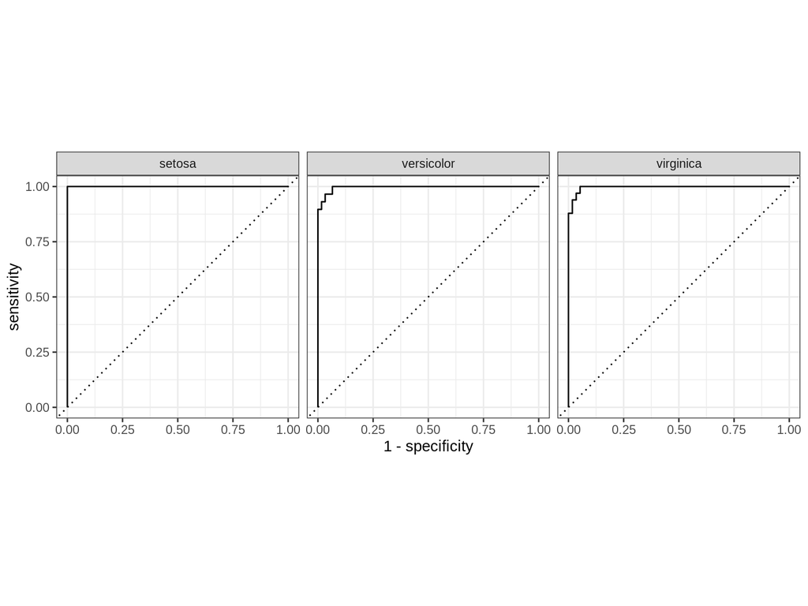

```r
iris_prob_train %>%
  roc_curve(Species, .pred_setosa:.pred_virginica) %>%
  autoplot()
```

# Model performance: confusion matrix (test set)

We can check for overfitting calculating performance metrics for the test set:

```r
iris_ranger_wf %>%
  predict(testing(iris_split)) %>%
  bind_cols(testing(iris_split)) %>%
  conf_mat(truth = Species, estimate = .pred_class)
```

```
##             Truth
## Prediction   setosa versicolor virginica
##   setosa         22          0         0
##   versicolor      0         18         0
##   virginica       0          3        17
```

# Model performance: metrics (test set)

```r
iris_ranger_wf %>%
  predict(testing(iris_split)) %>%
  bind_cols(testing(iris_split)) %>%
  class_metrics(truth = Species, estimate = .pred_class)
```

```
## # A tibble: 3 × 3
##   .metric   .estimator .estimate
##   <chr>     <chr>          <dbl>
## 1 accuracy  multiclass     0.95
## 2 precision macro          0.95
## 3 recall    macro          0.952
```

We observe a very good performance also on the test set.

See a binary classification workflow at: https://bit.ly/3O5HIup

# Regression with tidymodels

# A minimal regression workflow

Let’s consider the `BostonHousing` dataset from the `mlbench` package:

```r
library(mlbench)
data("BostonHousing")
BostonHousing %>% glimpse()
```

```
## Rows: 506
## Columns: 14
## $ crim    <dbl> 0.00632, 0.02731, 0.02729, 0.03237, 0.06905, 0.02985, 0.08829,…
## $ zn      <dbl> 18.0, 0.0, 0.0, 0.0, 0.0, 0.0, 12.5, 12.5, 12.5, 12.5, 12.5, 1…
## $ indus   <dbl> 2.31, 7.07, 7.07, 2.18, 2.18, 2.18, 7.87, 7.87, 7.87, 7.87, 7.…
## $ chas    <fct> 0, 0, 0, 0, 0, 0, 0, 0, 0, 0, 0, 0, 0, 0, 0, 0, 0, 0, 0, 0, 0,…
## $ nox     <dbl> 0.538, 0.469, 0.469, 0.458, 0.458, 0.458, 0.524, 0.524, 0.524,…
## $ rm      <dbl> 6.575, 6.421, 7.185, 6.998, 7.147, 6.430, 6.012, 6.172, 5.631,…
## $ age     <dbl> 65.2, 78.9, 61.1, 45.8, 54.2, 58.7, 66.6, 96.1, 100.0, 85.9, 9…
## $ dis     <dbl> 4.0900, 4.9671, 4.9671, 6.0622, 6.0622, 6.0622, 5.5605, 5.9505…
## $ rad     <dbl> 1, 2, 2, 3, 3, 3, 5, 5, 5, 5, 5, 5, 5, 4, 4, 4, 4, 4, 4, 4, 4,…
## $ tax     <dbl> 296, 242, 242, 222, 222, 222, 311, 311, 311, 311, 311, 311, 31…
## $ ptratio <dbl> 15.3, 17.8, 17.8, 18.7, 18.7, 18.7, 15.2, 15.2, 15.2, 15.2, 15…
## $ b       <dbl> 396.90, 396.90, 392.83, 394.63, 396.90, 394.12, 395.60, 396.90…
## $ lstat   <dbl> 4.98, 9.14, 4.03, 2.94, 5.33, 5.21, 12.43, 19.15, 29.93, 17.10…
## $ medv    <dbl> 24.0, 21.6, 34.7, 33.4, 36.2, 28.7, 22.9, 27.1, 16.5, 18.9, 15…
```

Our job is to predict the housing prices of the `medv` variable.

# Split into train and test sets

We use `initial_split` to build train and test sets:

```r
set.seed(2021)
bh_split <- initial_split(BostonHousing, prob = 0.8)
```

# Pre-processing with a recipe

```r
bh_recipe <- training(bh_split) %>%
  recipe(medv ~ .) %>%
  step_mutate(chas = as.numeric(chas)) %>%
  step_corr(all_predictors()) %>%
  step_nzv(all_predictors()) %>%
  prep()
```

- `step_mutate` changes the type of `chas` from factor to numeric,
- `step_corr` looks for correlated features,
- `step_nzv` looks for variables of low variance.

# Pre-processing with a recipe

```r
bh_recipe
```

```
## Recipe
##
## Inputs:
##
##       role #variables
##    outcome          1
##  predictor         13
##
## Training data contained 379 data points and no missing data.
##
## Operations:
##
## Variable mutation for ~as.numeric(chas) [trained]
## Correlation filter on tax [trained]
## Sparse, unbalanced variable filter removed <none> [trained]
```

# Building a model

We train a straight regression model using the `lm` function from R base:

```r
bh_lm <- linear_reg("regression") %>%
  set_engine("lm")
```

# Fitting the model

Let’s define a workflow to train the regression model with the training set:

```r
bh_lm_wf <- workflow() %>%
  add_recipe(bh_recipe) %>%
  add_model(bh_lm) %>%
  fit(training(bh_split))
```

# Fitting the model

```r
bh_lm_wf
```

```
## ══ Workflow [trained] ══════════════════════════════════════════════════════════
## Preprocessor: Recipe
## Model: linear_reg()
##
## ── Preprocessor ────────────────────────────────────────────────────────────────
## 3 Recipe Steps
##
## • step_mutate()
## • step_corr()
## • step_nzv()
##
## ── Model ───────────────────────────────────────────────────────────────────────
##
## Call:
## stats::lm(formula = ..y ~ ., data = data)
##
## Coefficients:
## (Intercept)         crim           zn        indus         chas          nox
##   25.949267    -0.111271     0.024262    -0.027314     3.492007   -15.973526
##          rm          age          dis          rad      ptratio            b
##    4.311976    -0.007512    -1.289722     0.118370    -1.052535     0.013149
##       lstat
##   -0.486000
```

# Predicting the train set

For each value $y_i$ of the train set, we obtain its prediction $\hat{y}_i$, and add it to the data:

```r
bh_lm_wf_pred <- bh_lm_wf %>%
  predict(training(bh_split)) %>%
  bind_cols(training(bh_split))
```

We have the real value and the prediction together in the same data frame:

```r
bh_lm_wf_pred %>%
  select(medv, .pred) %>%
  glimpse()
```

```
## Rows: 379
## Columns: 2
## $ medv  <dbl> 15.1, 25.0, 9.5, 17.1, 24.3, 13.1, 17.5, 20.9, 30.5, 14.2, 24.4,…
## $ .pred <dbl> 16.862292, 25.090698, 11.990740, 17.441328, 23.650521, 20.255728…
```

# Model performance in regression

We need parameters to assess how close predictions $\hat{y}_i$ are close to real values $y_i$ for a set of $n$ observations.

- **Root mean square error** `rmse`:

$$\sqrt{\frac{\sum \left( \hat{y}_i - y_i \right)^2}{n}}$$

- **Mean absolute error** `mae`:

$$\frac{\sum \vert \hat{y}_i - y_i \vert}{n}$$

- **R squared** $R^2$ `rsq` is the squared correlation between $\mathbf{y}$ and $\mathbf{\hat{y}}$.

# Model performance

Train set:

```r
bh_lm_wf_pred %>%
  metrics(truth = medv, estimate = .pred)
```

```
## # A tibble: 3 × 3
##   .metric .estimator .estimate
##   <chr>   <chr>          <dbl>
## 1 rmse    standard       4.68
## 2 rsq     standard       0.728
## 3 mae     standard       3.22
```

Test set:

```r
bh_lm_wf %>%
  predict(testing(bh_split)) %>%
  bind_cols(testing(bh_split)) %>%
  metrics(truth = medv, estimate = .pred)
```

```
## # A tibble: 3 × 3
##   .metric .estimator .estimate
##   <chr>   <chr>          <dbl>
## 1 rmse    standard       5.01
## 2 rsq     standard       0.746
## 3 mae     standard       3.43
```

# Evaluating alternative models

# How to evaluate alternative models

Usually we don’t have a single model, but we need to evaluate several alternatives:

- Several models,
- Several tuning parameters of a model,
- A combination of both.

We can’t use the test set for that, but we don’t want to select a model overfitting the train test.

# Resampling

[figure not shown]

Source: https://bookdown.org/max/FES/

# Cross validation

We split training data into *k* folds and perform *k* resamples.

- Use as validation set is each of the *k* folds, and as training set the other *k-1* folds,
- evaluate performance on each validation set,
- and average performance across *k* resamples.

Once chosen the model, we train it using the whole training set.

We use:

- `vfold_cv` from the `rsample` package to define folds,
- `fit_resamples` and `collect_metrics` from the `tune` package to evaluate models.

# An example of cross validation

Let’s define a workflow with the `bh_recipe` and `bh_lm` we have previously defined:

```r
bh_wf <- workflow() %>%
  add_recipe(bh_recipe) %>%
  add_model(bh_lm)
```

and define a cross-validation with five folds on the training set:

```r
set.seed(1212)
bh_folds <- vfold_cv(training(bh_split), v = 5)
```

and perform cross validation:

```r
fit_resamples(bh_wf, bh_folds) %>%
  collect_metrics()
```

```
## # A tibble: 2 × 6
##   .metric .estimator  mean     n std_err .config
##   <chr>   <chr>      <dbl> <int>   <dbl> <chr>
## 1 rmse    standard   4.94      5  0.501  Preprocessor1_Model1
## 2 rsq     standard   0.702     5  0.0352 Preprocessor1_Model1
```

We would do that with any other alternative model (e.g., regularized regression).

# Tuning models

# Hyperparameter tuning

The outcome of some models depends on the value of some variables set to obtain parameters, we call these variables **hyperparameters**.

In random forests:

- `mtry`: The number of predictors that will be randomly sampled at each split when creating the tree models.
- `trees`: The number of trees contained in the ensemble.

https://parsnip.tidymodels.org/reference/rand_forest.html

# Elements for hyperparameter tuning

We use `expand.grid` to define a **tuning grid**:

```r
rf_grid <- expand.grid(mtry = c(1, 5, 10), trees = c(5, 10, 15))
rf_grid
```

```
##   mtry trees
## 1    1     5
## 2    5     5
## 3   10     5
## 4    1    10
## 5    5    10
## 6   10    10
## 7    1    15
## 8    5    15
## 9   10    15
```

# Elements for hyperparameter tuning

We define the **model** specifying that we want to `tune()` hyperparameters `mtry` and `trees`:

```r
bh_rf <- rand_forest(mode = "regression", mtry = tune(), trees = tune()) %>%
  set_engine("ranger")
```

Other elements:

- the **preprocessing** recipe `bh_recipe`,
- the **cross-validation** folders `bh_folds`.

We will train the model 5 times for each of the 9 values of the tuning grid.

# Performing hyperparameter tuning

Let’s tune the model (this takes time):

```r
rf_tune <- tune_grid(object = bh_rf,
                     preprocessor = bh_recipe,
                     resamples = bh_folds,
                     grid = rf_grid,
                     metrics = metric_set(rmse, mae))
```

Results:

```r
show_best(rf_tune, metric = "mae")
```

```
## # A tibble: 5 × 8
##    mtry trees .metric .estimator  mean     n std_err .config
##   <dbl> <dbl> <chr>   <chr>      <dbl> <int>   <dbl> <chr>
## 1    10    10 mae     standard    2.48     5  0.195  Preprocessor1_Model6
## 2     5    10 mae     standard    2.57     5  0.154  Preprocessor1_Model5
## 3    10    15 mae     standard    2.59     5  0.230  Preprocessor1_Model9
## 4     5    15 mae     standard    2.61     5  0.207  Preprocessor1_Model8
## 5     5     5 mae     standard    2.61     5  0.0894 Preprocessor1_Model2
```

# Classification with imbalanced data

# Imbalanced data

It is usual that in classification problems we have an unequal distribution of observations across classes, usually with less observations in the positive class. These are **imbalanced datasets**.

Imbalanced data problems are frequent in business analytics:

- credit card fraud
- bankruptcy prevention
- …

# An imbalanced dataset

Let’s pick an artificial dataset with imbalanced data:

```r
imbal_data <-
  readr::read_csv("https://bit.ly/imbal_data") %>%
  mutate(Class = factor(Class))
```

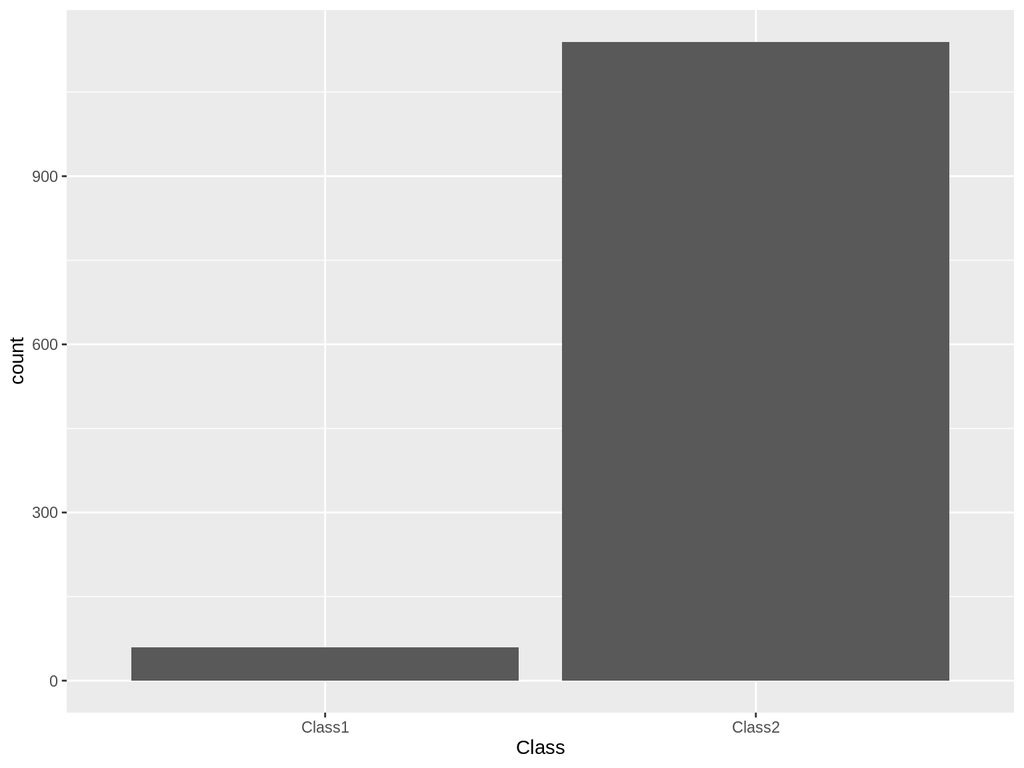

# A training workflow

Let’s split into train and test, maintaining the same proportion of positives in train and test sets with `strata = "Class"`:

```r
set.seed(1122)
imbal_split <- initial_split(imbal_data, prop = 0.8, strata = "Class")
```

We will use a quadratic **discriminant analysis model (QDA)** to train the data:

```r
library(discrim)
qda_mod <- discrim_regularized(frac_common_cov = 0, frac_identity = 0) %>%
  set_engine("klaR")
```

And build the workflow to fit the model with the train set:

```r
qda_wflw <-
  workflow() %>%
  add_model(qda_mod) %>%
  add_formula(Class ~ .) %>%
  fit(training(imbal_split))
```

# Evaluating with cross validation

Let’s use cross validation to evaluate the classifier with five folds and five repeats:

```r
set.seed(5732)
cv_folds <- vfold_cv(training(imbal_split),
                     strata = "Class",
                     v=5, repeats = 5)
```

Let’s define a set of classification metrics:

```r
cls_metrics <- metric_set(accuracy, sens, spec)
```

# What are the results?

```r
set.seed(2180)
qda_res <- fit_resamples(
  qda_wflw,
  resamples = cv_folds,
  metrics = cls_metrics)
```

```r
collect_metrics(qda_res)
```

```
## # A tibble: 3 × 6
##   .metric  .estimator  mean     n std_err .config
##   <chr>    <chr>      <dbl> <int>   <dbl> <chr>
## 1 accuracy binary     0.955    25 0.00286 Preprocessor1_Model1
## 2 sens     binary     0.236    25 0.0296  Preprocessor1_Model1
## 3 spec     binary     0.994    25 0.00105 Preprocessor1_Model1
```

# Imbalanced data in classification

Applying the usual workflow to imbalanced data in classification problems usually obtain:

- high accuracy and specificity.
- low sensitivity.

These are not good news (think of a credit card fraud detection project)…

# Subsampling for imbalanced data

We can test the possibility of **subsampling** if we obtain poor performance in imbalanced classification problems:

- **Undersampling** or **downsampling** means reducing the number of observations of the majority class to obtain a balanced dataset.
- **Oversampling** or **upsampling** consists of creating additional observations of the minority class to obtain a balanced dataset.
- https://www.tidymodels.org/learn/models/sub-sampling/

# Subsampling in tidymodels

Subsampling in `tidymodels` is done with the `themis` package. It extends the functionality of `recipes` adding steps to subsample imbalanced data

The default recipes for subsampling are:

- `step_subsample` for undersampling,
- `step_upsample` for oversampling.

For more recipes, see:

https://github.com/tidymodels/themis

If `themis` recipes are used with the default mode `skip = TRUE`:

- the model is fit with the subsampled dataset,
- and predictions are computed with the original dataset.

# A workflow with subsampling: evaluating the model

Let’s train a model for `imbal_data` with oversampling using the ***ROSE** algorithm (Randomly Over Sampling Examples). Let’s use the `step_rose` recipe from the `themis` package:

```r
library(themis)
imbal_rec <-
  recipe(Class ~ ., data = imbal_data) %>%
  step_rose(Class)
```

… add the recipe to the `qda_rose_wflw` workflow:

```r
qda_rose_wflw <-
  workflow() %>%
  add_model(qda_mod) %>%
  add_recipe(imbal_rec)
```

… and assess the model using cross validation:

```r
set.seed(2180)
qda_rose_res <- fit_resamples(
  qda_rose_wflw,
  resamples = cv_folds,
  metrics = cls_metrics)
```

# Results of non-subsampled and subsampled models

Let’s compare the results of the non-subsampled model:

```r
collect_metrics(qda_res)
```

```
## # A tibble: 3 × 6
##   .metric  .estimator  mean     n std_err .config
##   <chr>    <chr>      <dbl> <int>   <dbl> <chr>
## 1 accuracy binary     0.955    25 0.00286 Preprocessor1_Model1
## 2 sens     binary     0.236    25 0.0296  Preprocessor1_Model1
## 3 spec     binary     0.994    25 0.00105 Preprocessor1_Model1
```

… with the subsampled model:

```r
collect_metrics(qda_rose_res)
```

```
## # A tibble: 3 × 6
##   .metric  .estimator  mean     n std_err .config
##   <chr>    <chr>      <dbl> <int>   <dbl> <chr>
## 1 accuracy binary     0.893    25 0.00397 Preprocessor1_Model1
## 2 sens     binary     0.818    25 0.0263  Preprocessor1_Model1
## 3 spec     binary     0.897    25 0.00405 Preprocessor1_Model1
```

# A workflow with subsampling: predicting train and test

Let’s predict train and test sets with the subsampled model, and assess model performance in both sets:

```r
fit_rose <- qda_rose_wflw %>%
  fit(training(imbal_split))
```

```r
predict_rose_train <- fit_rose %>%
    predict(training(imbal_split)) %>%
    bind_cols(training(imbal_split))
```

```r
predict_rose_test <- fit_rose %>%
    predict(testing(imbal_split)) %>%
    bind_cols(testing(imbal_split))
```

# A workflow with subsampling: confusion matrices

```r
predict_rose_train %>%
    conf_mat(truth = Class, estimate = .pred_class)
```

```
##           Truth
## Prediction Class1 Class2
##     Class1     49     96
##     Class2      0    815
```

```r
predict_rose_test %>%
    conf_mat(truth = Class, estimate = .pred_class)
```

```
##           Truth
## Prediction Class1 Class2
##     Class1     10     29
##     Class2      1    200
```

# A workflow with subsampling: performance metrics

```r
cls_metrics <- metric_set(accuracy, sens, spec)
```

```r
predict_rose_train %>%
  cls_metrics(truth = Class, estimate = .pred_class)
```

```
## # A tibble: 3 × 3
##   .metric  .estimator .estimate
##   <chr>    <chr>          <dbl>
## 1 accuracy binary         0.9
## 2 sens     binary         1
## 3 spec     binary         0.895
```

```r
predict_rose_test %>%
  cls_metrics(truth = Class, estimate = .pred_class)
```

```
## # A tibble: 3 × 3
##   .metric  .estimator .estimate
##   <chr>    <chr>          <dbl>
## 1 accuracy binary         0.875
## 2 sens     binary         0.909
## 3 spec     binary         0.873
```

# Results of subsampling

When we apply subsampling to imbalanced data we can be able to obtain:

- lower values of accuracy and specificity,
- but better values of sensitivity.

This can be a good tradeoff if we are concerned with detecting positives as accurately as possible. We must take into account that:

- Some classification techniques may work better with subsampling than others,
- Some subsampling recipes like `step_rose` with with numeric features only.